# Permutations

Maggy Critchlow

1/12/2021

## Required Packages and Data

```r
library(tidyverse)
rollSummary <- tibble(value = 1:6,
                      n = c(8,9,18,7,8,10))
rollSummary
```

```
## # A tibble: 6 x 2
##   value     n
##   <int> <dbl>
## 1     1     8
## 2     2     9
## 3     3    18
## 4     4     7
## 5     5     8
## 6     6    10
```

The above object contains the results from rolling a die 60 times. We’re aiming to find out, using a permutation test, the probability of obtaining these results if this isn’t a cheaty die.

## A Dice-y Situation

Fortunately, this goal isn’t too difficult. It only requires slightly modifying the code presented in class. First, we’ll calculate the $\chi$<sup>2</sup> for the observed data.

```r
n <- 60
Expected <- rep(10,6)
Observed <- rollSummary$n
obsXsq <- sum((Observed - Expected)^2 / Expected)
obsXsq
```

```
## [1] 8.2
```

Sticking with the 1000 permutations, a loop can be set up as follows. This follows essentially the same setup as the fuzzy alpaca example, mixed with the simulated fair die roll code.

```r
possibleValues <- seq(1,6,by=1)
m <- 1e3
XStatPermute <- numeric()
set.seed(1)
for(i in 1:m){
  ranRolls <- tibble(value=sample(x = possibleValues,
                                  size = n,
                                  replace = TRUE))
  ranRollsSummary <- ranRolls %>% count(value)
  ranRollsSummary
  XStatPermute[i] <- sum((ranRollsSummary$n - Expected)^2 / Expected)
}
head(XStatPermute)
```

```
## [1] 6.2 0.6 3.8 7.2 4.8 3.0
```

Success!

## Know When to Hold ’Em, Know When to Fold ’Em

The next step is calculating the p-value, or the probability that we would obtain our results if the die was actually fair.

```r
pval <- sum(XStatPermute > obsXsq) / m
pval
```

```
## [1] 0.149
```

This indicates that 149 randomizations, out of 1000, had a higher $\chi$<sup>2</sup> value than our observed one. If we’re sticking with statistical convention, this p-value is greater than 0.05, and so we would fail to reject the null hypothesis that our results are significantly diffent than random rolls of a fair die. But with approximately 85% of the simulated results having a lower $\chi$<sup>2</sup> value, I wouldn’t be surprised at a gambler walking away.

## Density Visualization

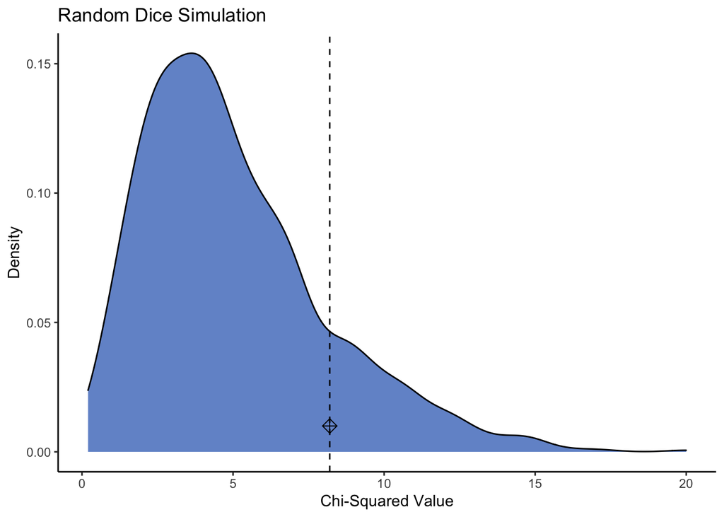

```r
plot1 <- ggplot() +
  geom_density(aes(x = XStatPermute), fill = "#4978c4", alpha = 0.8) +
  geom_vline(xintercept = obsXsq, color="black", linetype="dashed") +
  geom_point(aes(x = obsXsq, y = 0.01), size = 3, pch = 9,color="black") +
  labs(title = "Random Dice Simulation", y="Density", x="Chi-Squared Value") + theme_classic() +
  theme(legend.position="none")
plot1
```

Like the p-value, this shows an observed value that is not wildly different from the simulated values, but doesn’t exactly fall right in the middle of the distribution.

## Die-secting Permutations

I promise that’s it for the awful headings.

Is the die fair? The stats say yes. With an alpha of 0.05, we’d fail to reject the null hypothesis. Without going too far off-topic, if we were really concerned about identifying an unfair die, we could determine the probability of a type II (false negative) error and set a different alpha that way. In addition, although this result is unlikely, it’s certainly far from impossible. A fair coin can land on heads 10 (or 50, or 100) times in a row, after all. But I would understand why someone might ask the question after seeing the results.

Out of curiosity, I changed `m` to run the simulation 10,000 times. It changed my results slightly (p = 0.139), but I wouldn’t consider this a meaningful difference. 1000 permutations should be sufficient to get an idea of what a truly random data set (which we would expect with a fair die) would look like.

The permutation test provides a straightforward, assumption-free method to test a hypothesis using resampling methods. Using randomization, we are able to come up with a probability of an observed result if that result was due to chance.